# Customisation of Linear Regression

So first I am going to include the code from the first two exercises in the notebook which dont use a specific data set first and then I am going to customise my own linear regression using the diabetes dataset.

### 1a: Gaussian Likelihood Function

Write a function to compute the likelihood of observing a set of values under a normal distribution with mean mu and variance sigma^2. The function should accept an observation Y, a mean value mu, and a standard deviation sigma, and return the likelihood of observing Y under these parameters.

```python
import numpy as np

def normal_pdf(y, mu, sigma):
    """Calculate the probability density of y under a Gaussian distribution with mean mu and standard deviation sigma."""
    factor = 1 / (sigma * np.sqrt(2 * np.pi))
    exponent = -((y - mu) ** 2) / (2 * sigma ** 2)
    return factor * np.exp(exponent)
```

### 1b: Likelihood Under Standard Normal Model

Generate a sequence of values from -5 to 5 (with a step of 0.1) and calculate the likelihood of each value under a Standard Normal model (mu=0, sigma=1). Plot these likelihood values and discuss the shape of the plot.

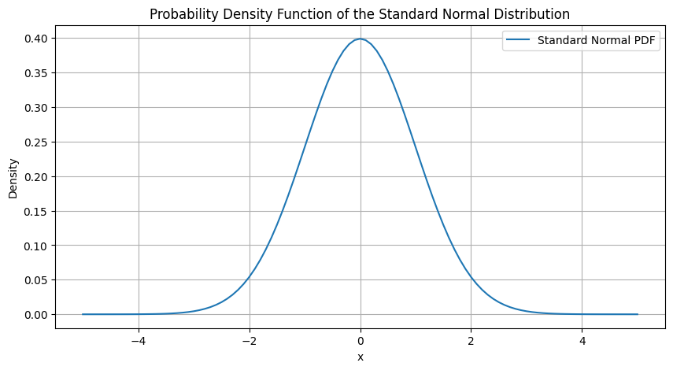

```python
import matplotlib.pyplot as plt

# Generate a sequence of values from -5 to 5 with a step of 0.1
x_values = np.arange(-5, 5.1, 0.1)

# Calculate the likelihood of each value under a standard normal distribution
mu = 0
sigma = 1
likelihoods = np.exp(-(x_values - mu)**2 / (2 * sigma**2)) / (sigma * np.sqrt(2 * np.pi))

# Plot these likelihood values
plt.figure(figsize=(10, 5))
plt.plot(x_values, likelihoods, label='Standard Normal PDF')
plt.title('Probability Density Function of the Standard Normal Distribution')
plt.xlabel('x')
plt.ylabel('Density')
plt.grid(True)
plt.legend()
plt.show()
```

## Exercise 2: Exploring the Gamma Distribution and the Central Limit Theorem

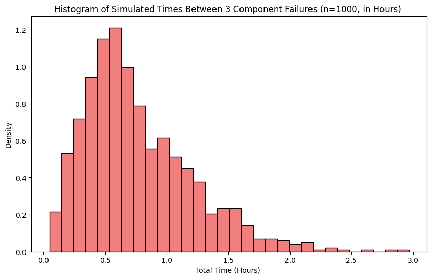

```python
# Parameters for the new simulation

n_new = 1000 # Number of simulations
alpha = 3# Number of component failures
rate_per_minute = 1 / 15 # Rate of failure per 15 minutes
rate_per_hour = rate_per_minute * 60 # Convert rate to failures per hour

#Simulate n_new instances of time between 3 component failures in hours

failure_times_hours = np.random.gamma(shape=alpha,scale = 1/rate_per_hour, size = n_new)

#Plot the histogram

plt. figure(figsize=(10, 6))
plt.hist(failure_times_hours, bins=30, color='lightcoral', edgecolor='black', density=True)
plt.title( 'Histogram of Simulated Times Between 3 Component Failures (n=1000, in Hours) ')
plt.xlabel( 'Total Time (Hours) ')
plt.ylabel('Density' )
plt.show()
```

### 2b: Analyze Distribution Properties

Using the sample generated, calculate the following:

1. **Mean:** The average value of the sample.
2. **Standard Deviation:** Measure of spread around the mean.
3. **Variance:** Square of the standard deviation.
4. **Skewness:** Measure of asymmetry of the distribution.

```python
import numpy as np
import scipy.stats as stats

# Parameters
alpha = 3  # shape parameter for the Gamma distribution
beta = 1 / (15 / 60)  # rate parameter converted to hours (1 failure every 15 minutes)
n = 1000  # number of instances to simulate

# Generate gamma-distributed observations
sample = np.random.gamma(alpha, 1/beta, n)

# Calculate distribution properties
mean = np.mean(sample)
std_dev = np.std(sample)
variance = np.var(sample)
skewness = stats.skew(sample)

# Print the results
print(f"Mean: {mean:.3f} ")
print(f"Standard Deviation: {std_dev:.3f} ")
print(f"Variance: {variance:.3f} ")
print(f"Skewness: {skewness:.3f}")
```

```
Mean: 0.736
Standard Deviation: 0.431
Variance: 0.185
Skewness: 1.338
```

### 1c: Central Limit Theorem in Action

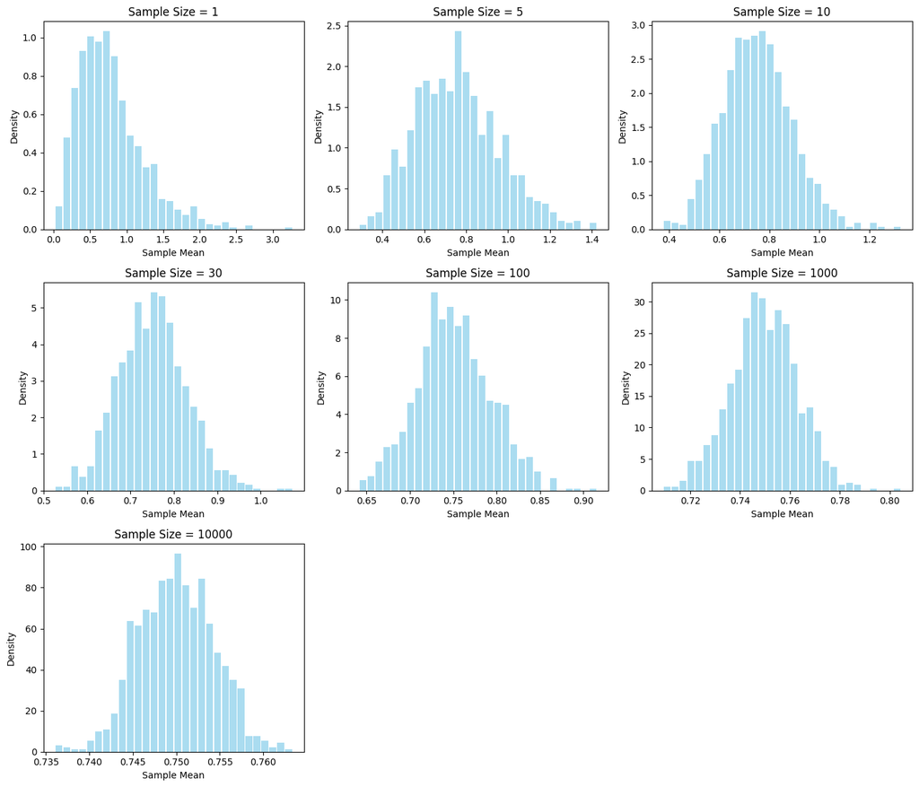

```python
import numpy as np
import matplotlib.pyplot as plt
from scipy.stats import gamma, norm

def generate_sample_means(sample_size, num_samples=1000):
    """Generate sample means for Gamma-distributed data."""
    means = []
    for _ in range(num_samples):
        # Generate a sample and compute its mean
        sample = np.random.gamma(alpha, 1/beta, sample_size)
        sample_mean = np.mean(sample)
        means.append(sample_mean)
    return means

# Define sample sizes to test
sample_sizes = [1, 5, 10, 30, 100, 1000, 10000]

# Plotting the histogram of sample means for different sample sizes
plt.figure(figsize=(14, 12))
for i, size in enumerate(sample_sizes, 1):
    plt.subplot(3, 3, i)
    means = generate_sample_means(size)
    plt.hist(means, color='skyblue', alpha=0.7, rwidth=0.85, density = True, bins = 30)
    plt.title(f'Sample Size = {size}')
    plt.xlabel('Sample Mean')
    plt.ylabel('Density')

plt.tight_layout()
plt.show()
```

# Customisation of 'Playing with Linear Regression'

I am using the Diabetes Data Set as I myself was diagnosed with Type 1 Diabetes and thought it was interesting to see how good models are at predicting diabetes.

**So the aim of the notebook is to use the diabetes dataset to predict the progression of diabetes one year after baseline, with the target value being a quantitative measure of disease progression based on physiological measurements.**

## Importing Packages

First, we need to import the necessary packages to load the dataset as it is part of the `sklearn.datasets`.

## Exploring the Dataset

Let's take a look at the dataset and see what is inside:

### Data Set Characteristics:

- **Number of Instances:** 442
- **Number of Attributes:** The first 10 columns are numeric predictive values.
- **Target:** Column 11 is a quantitative measure of disease progression one year after baseline.

### Attribute Information:

- **age**: Age in years
- **sex**
- **bmi**: Body Mass Index
- **bp**: Average blood pressure
- **s1**: tc, total serum cholesterol
- **s2**: ldl, low-density lipoproteins
- **s3**: hdl, high-density lipoproteins
- **s4**: tch, total cholesterol / HDL
- **s5**: ltg, possibly log of serum triglycerides level
- **s6**: glu, blood sugar level

```python
import pandas as pd
import numpy as np
import statsmodels.api as sm
import matplotlib.pyplot as plt

# Load the diabetes dataset from statsmodels or sklearn
from sklearn.datasets import load_diabetes

# Load the dataset and convert to DataFrame
data = load_diabetes(as_frame=True)
df = data.frame

# Add a target column name
# The target is the diabetes progression based on physiological measurements
df['target'] = data.target
print(df.head())
```

```
        age       sex       bmi        bp        s1        s2        s3  \
0  0.038076  0.050680  0.061696  0.021872 -0.044223 -0.034821 -0.043401
1 -0.001882 -0.044642 -0.051474 -0.026328 -0.008449 -0.019163  0.074412
2  0.085299  0.050680  0.044451 -0.005670 -0.045599 -0.034194 -0.032356
3 -0.089063 -0.044642 -0.011595 -0.036656  0.012191  0.024991 -0.036038
4  0.005383 -0.044642 -0.036385  0.021872  0.003935  0.015596  0.008142

         s4        s5        s6  target
0 -0.002592  0.019907 -0.017646   151.0
1 -0.039493 -0.068332 -0.092204    75.0
2 -0.002592  0.002861 -0.025930   141.0
3  0.034309  0.022688 -0.009362   206.0
4 -0.002592 -0.031988 -0.046641   135.0
```

## Feature Engineering

To enhance the dataset, I introduced a **lagged_bmi** feature by shifting BMI values down one row and categorized the **age** variable into three groups: young, middle-aged, and old.

These engineered features were designed to capture age-related trends. For instance, the age categories help identify potential differences in diabetes progression across life stages, while the **lagged_bmi** feature introduces a time-sensitive element to the analysis.

```python
# Add a lag feature for BMI
df['lagged_bmi'] = df['bmi'].shift(1)

# Discretize age into bins and create dummy variables
df['age_category'] = pd.cut(df['age'], bins=3, labels=['young', 'middle-aged', 'old'])
age_dummies = pd.get_dummies(df['age_category'], prefix='age', drop_first=True)

# Concatenate dummy variables with the main DataFrame
df = pd.concat([df, age_dummies], axis=1)

# Drop missing rows due to lagging
df = df.dropna()
```

```python
# Define the independent (X) and dependent (y) variables
X = df[['bmi', 'lagged_bmi', 'age_middle-aged', 'age_old']]
X_with_const = sm.add_constant(X)  # Add a constant term for the intercept
y = df['target']
```

# Regression Model Fitting

Next we fitted a OLS regression model using both original and engineered features.

```python
# Define the independent (X) and dependent (y) variables
X = df[['bmi', 'lagged_bmi', 'age_middle-aged', 'age_old']]
X_with_const = sm.add_constant(X)  # Add a constant term for the intercept
y = df['target']

X_with_const['age_middle-aged'] = X_with_const['age_middle-aged'].astype(float)
X_with_const['age_old'] = X_with_const['age_old'].astype(float)

# Fit the linear regression model
model = sm.OLS(y, X_with_const).fit()

# Print the model summary
print(model.summary())
```

```
                            OLS Regression Results
==============================================================================
Dep. Variable:                 target   R-squared:                       0.353
Model:                            OLS   Adj. R-squared:                  0.347
Method:                 Least Squares   F-statistic:                     59.37
Date:                Fri, 06 Dec 2024   Prob (F-statistic):           5.29e-40
Time:                        01:00:40   Log-Likelihood:                -2446.0
No. Observations:                 441   AIC:                             4902.
Df Residuals:                     436   BIC:                             4922.
Df Model:                           4
Covariance Type:            nonrobust
===================================================================================
                      coef    std err          t      P>|t|      [0.025      0.975]
-----------------------------------------------------------------------------------
const             145.8203      5.820     25.055      0.000     134.381     157.259
bmi               935.9097     63.315     14.782      0.000     811.470    1060.350
lagged_bmi        -32.1467     62.655     -0.513      0.608    -155.291      90.997
age_middle-aged     4.7149      7.199      0.655      0.513      -9.434      18.863
age_old            17.5082      8.524      2.054      0.041       0.755      34.262
==============================================================================
Omnibus:                       13.767   Durbin-Watson:                   1.846
Prob(Omnibus):                  0.001   Jarque-Bera (JB):                8.190
Skew:                           0.164   Prob(JB):                       0.0167
Kurtosis:                       2.419   Cond. No.                         24.8
==============================================================================

Notes:
[1] Standard Errors assume that the covariance matrix of the errors is correctly specified.
```

The results indicate that **BMI** has a substantial impact on diabetes progression, with a coefficient of approximately **935.91**. This means each unit increase in BMI corresponds to a significant rise in the target measure. The R-squared value of **0.353** suggests that the model explains 35.3% of the variance, leaving room for further improvements.

# Inference by Approximate Posterior Simulations

I performed Monte Carlo simulations using the regression coefficients to assess their variability and compute confidence intervals.

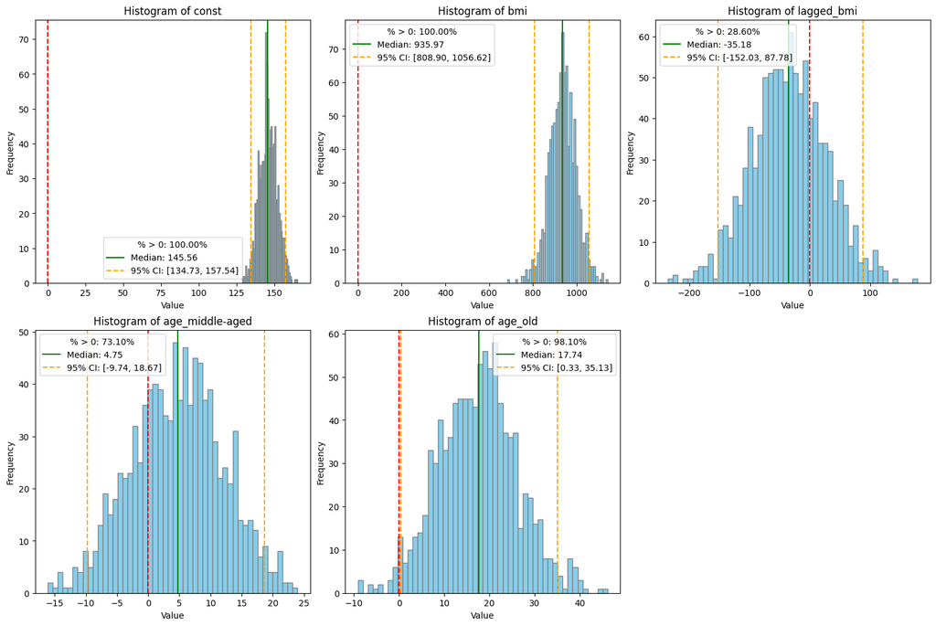

```python
# Simulate values from empirical posterior distribution
coeff_samples = np.random.multivariate_normal(model.params, model.cov_params(), 1000)

# Extract parameter names dynamically
parameter_names = model.params.index.tolist()
n_params = len(parameter_names)

# Plotting histograms for coefficients
n_cols = min(3, n_params)
n_rows = (n_params + n_cols - 1) // n_cols

fig, axes = plt.subplots(n_rows, n_cols, figsize=(n_cols * 5, n_rows * 5), constrained_layout=True)
axes_flat = axes.flatten()

for i, name in enumerate(parameter_names):
    mean_val = np.mean(coeff_samples[:, i])
    median_val = np.median(coeff_samples[:, i])
    ci_lower, ci_upper = np.percentile(coeff_samples[:, i], [2.5, 97.5])
    percent_positive = np.mean(coeff_samples[:, i] > 0) * 100

    ax = axes_flat[i]
    ax.hist(coeff_samples[:, i], bins=50, color='skyblue', edgecolor='gray')
    ax.axvline(x=median_val, color='green', linestyle='-', label=f'Median: {median_val:.2f}')
    ax.axvline(x=ci_lower, color='orange', linestyle='--', label=f'95% CI: [{ci_lower:.2f}, {ci_upper:.2f}]')
    ax.axvline(x=ci_upper, color='orange', linestyle='--')
    ax.axvline(x=0, color='red', linestyle='--')
    ax.set_title(f'Histogram of {name}')
    ax.set_xlabel('Value')
    ax.set_ylabel('Frequency')
    ax.legend(title=f'% > 0: {percent_positive:.2f}%')

# Hide unused subplots
for j in range(i + 1, len(axes_flat)):
    axes_flat[j].set_visible(False)

plt.show()
```

# Generating Predicted Values and Estimating Statistics

```python
# Predict new values (fitted values)
new_predictions = model.predict(X_with_const)

# Simulate fitted values
fitted_value_samples = X_with_const @ coeff_samples.T

# Calculate median and prediction intervals for fitted values
monte_carlo_medians = np.median(fitted_value_samples, axis=1)
prediction_intervals = np.percentile(fitted_value_samples, [2.5, 97.5], axis=1)

# Print results
print("Median of fitted values (per observation):", monte_carlo_medians)
print("95% Prediction intervals:", prediction_intervals)
```

[output not shown]

[output cut: 212 more lines]

[output not shown]

```python
print(monte_carlo_medians.shape)
print(y.shape)
```

```
(441,)
(441,)
```

```python
print(type(monte_carlo_medians), monte_carlo_medians.dtype)
print(type(y), y.dtype)
```

```
<class 'numpy.ndarray'> float64
<class 'pandas.core.series.Series'> float64
```

```python
monte_carlo_medians = pd.to_numeric(monte_carlo_medians, errors='coerce')
```

# Evaluation and Visualization

I evaluated Model performance through scatter plots comparing predictions and actual values, as well as metrics such as correlation and RMSE.

```python
from sklearn.metrics import mean_squared_error

# Calculate metrics
correlation = np.corrcoef(monte_carlo_medians, y)[0, 1]
rmse = np.sqrt(mean_squared_error(y, monte_carlo_medians))
bias = np.mean(monte_carlo_medians - y)
coverage = np.mean((y >= prediction_intervals[0, :]) & (y <= prediction_intervals[1, :]))
```

```python
rmse
```

```
62.037910415691826
```

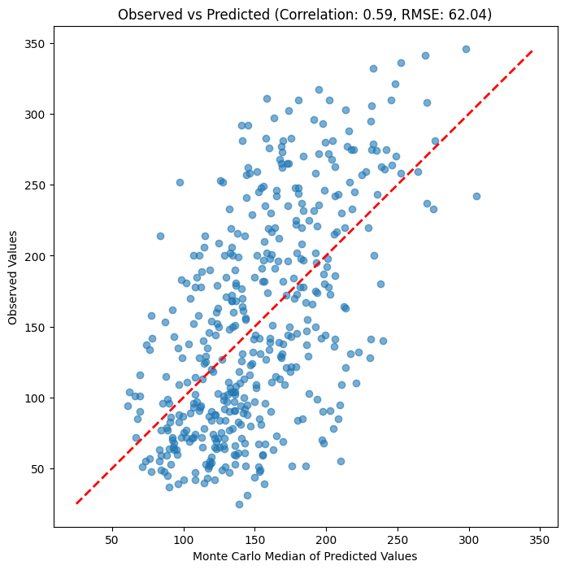

```python
# Observed vs Predicted Values Plot
plt.figure(figsize=(8, 8))
plt.scatter(monte_carlo_medians, y, alpha=0.6)
plt.plot([y.min(), y.max()], [y.min(), y.max()], color='red', linestyle='--', linewidth=2)
plt.xlabel('Monte Carlo Median of Predicted Values')
plt.ylabel('Observed Values')
plt.title(f'Observed vs Predicted (Correlation: {correlation:.2f}, RMSE: {rmse:.2f})')
plt.show()
```